# Week 5 progress report for upgrading thyrosim

benjamin chu

5/3/2017

## Refitting ideal weight curve

Last week we obtained the fitted ideal weight formula and the regression data. Our ideal weight formula predicts that a 170cm male should have an ideal weight of 73.1 kg, but from Feldschuh’s paper, 73.1kg seems to be overestimating a little bit (should be around 72). Since clicking is prone to manual error, I re-clicked the ideal weight data from Feldschuh’s graph again to ensure our results are accurate.

Last week’s ideal weight formula:
$$IW_{male} = 200.3 - 2.557 h + 0.01064 h^2.$$
$$IW_{female} = 150.4 - 1.938 h + 0.008504h^2$$

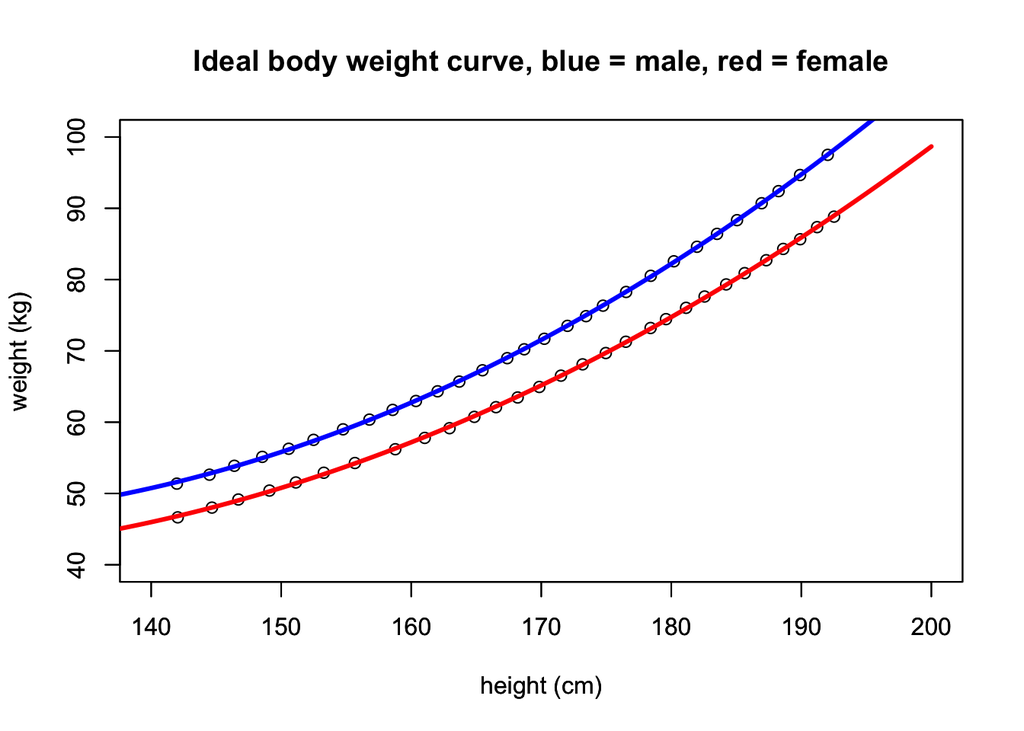

## Fitting monotonic function

Another problem with the regression fit we had last week was that the fitted curves were not monotonic. Contrary to physical intuition, the blood volume per kg for very fat people actually starts to increase. So, we tried to fit a monotonic curve this week. The result is as follows.

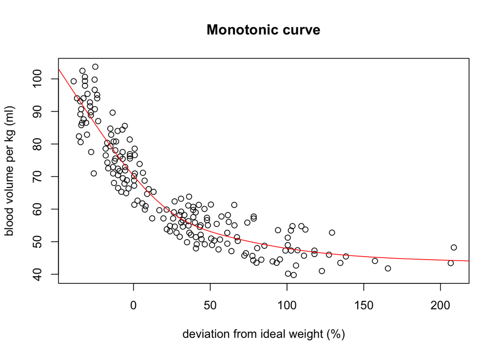

## How to get the red curve?

Unfortunately, the code for fitting the curve above was copied from a forum, and the solution is very convoluted. We couldn’t directly obtain the fitted curve. However, the general idea is that data are transformed into a monotonic table, which I have access to, and I could fit a polynomial to this data. While this introduces a second layer of potential bias, it is probably alright.

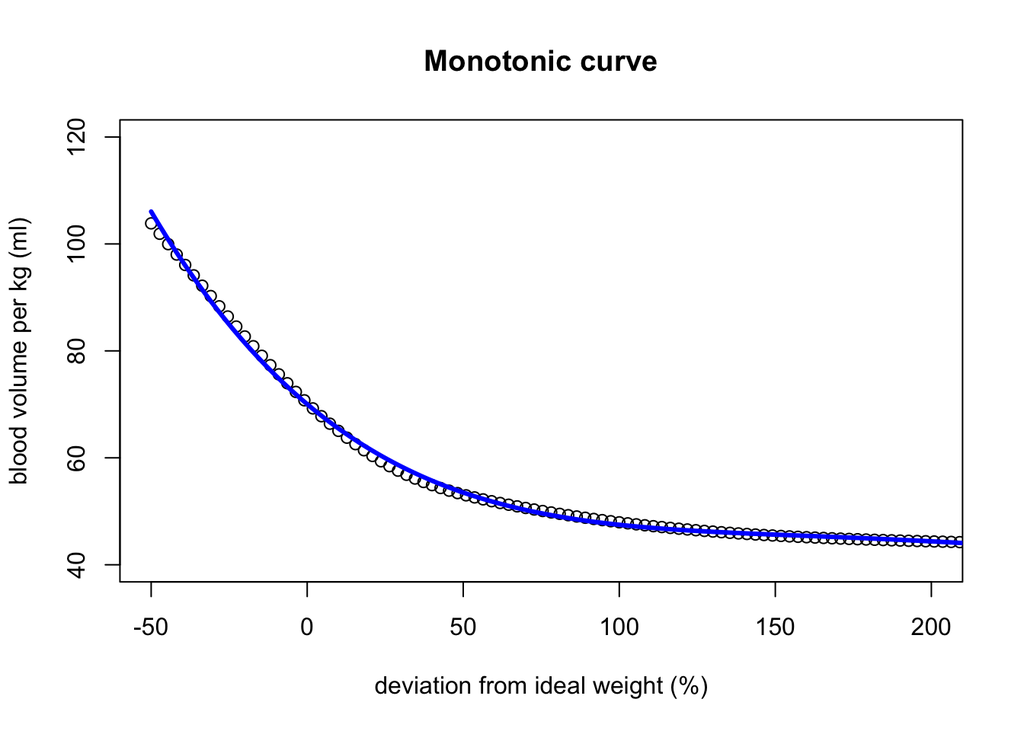